# Chi-square goodness of fit test

Harsha Achyuthuni

July 16 2019

In this post, I would like to look into Chi-sq goodness of fit test.  
During Uni-variate analysis in EDA from the attendance data set, I tried to explain using q-q plot that the feature ‘out-time-diff’ is not normally distributed. To statistically prove the same, we need to use chi square tests.

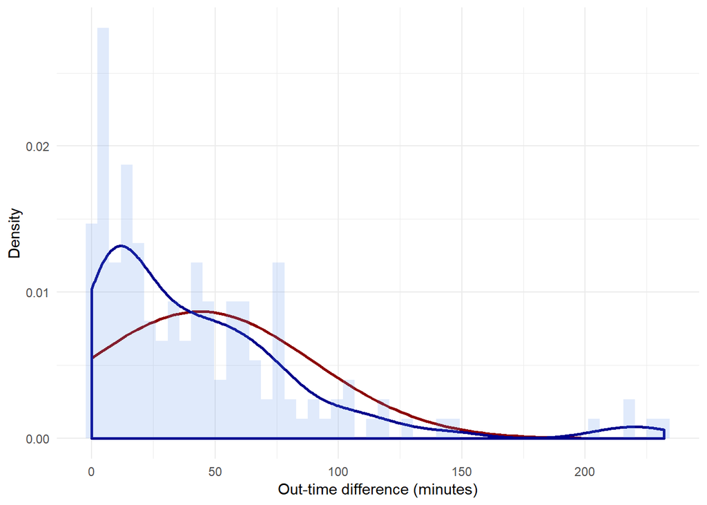

```r
ggplot(data,aes(x = alt.distr)) +
  stat_function(fun = dnorm, color="darkred",  size = 1,
                args = list(mean = mean(data$alt.distr),
                                         sd = sd(data$alt.distr) )) +
  geom_density(aes(y=..density..), color="darkblue",  size = 1)+
  geom_histogram(aes(y=..density..), bins = 50, fill = "cornflowerblue", alpha = 0.2) +
  labs(x = 'Out-time difference (minutes)', y='Density') +
  theme_minimal()
```

The q-q plot for reference:

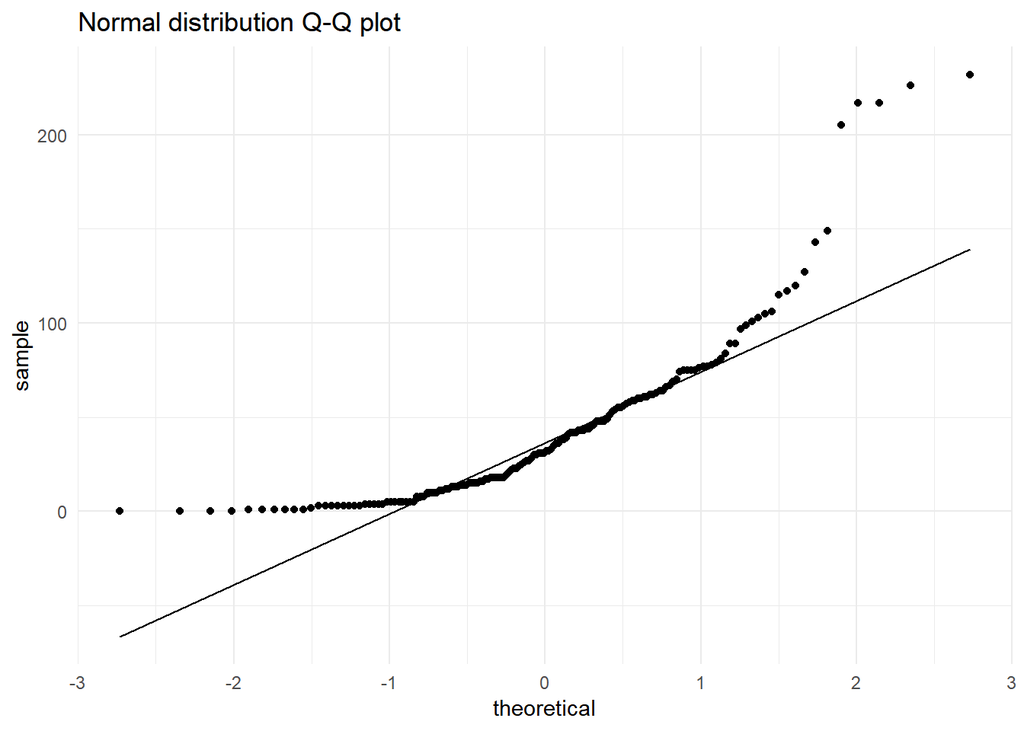

```r
ggplot(data,aes(sample = alt.distr)) +
  stat_qq() + stat_qq_line() +
  ggtitle("Normal distribution Q-Q plot") +
  theme_minimal()
```

The chi-square goodness of fit test for each group would have the following hypothesis:  
H0: There is no statistically significant difference between the observed frequencies of ‘diff-in-time’ and expected frequencies from a normal distribution  
H1: There is a statistically significant difference

The number of intervals is given by the formula,

```r
N <- floor(1+3.3*log10(length(data$alt.distr)))
```

The observed and expected frequencies considering the normal distribution are as follows:

```r
minimum.dist <- min(data$alt.distr)
maximum.dist <- max(data$alt.distr)
n <- length(data$alt.distr)
dist.mean <- mean(data$alt.distr)
dist.sd <- sd(data$alt.distr)
range.group <- (maximum.dist - minimum.dist)/N
data <- data %>% mutate(class = floor(alt.distr/range.group),
                        class_name_min =  minimum.dist + class*range.group,
                        class_name_max = minimum.dist + (class+ 1)*range.group,
                        class_name = paste0(class_name_min, '-', class_name_max))
chi.sq.table <- data %>% group_by(class, class_name) %>% summarise(obs_freq = n(),
                                                                   class_name_min = mean(class_name_min),
                                                                   class_name_max = mean(class_name_max)) %>%
  mutate(exp_freq = pnorm(class_name_max, dist.mean, dist.sd)*n - pnorm(class_name_min, dist.mean, dist.sd)*n,
         chi.sq = ((obs_freq - exp_freq)^2)/exp_freq)
```

```r
library(kableExtra)
kable(chi.sq.table %>% dplyr::select(class_name, obs_freq, exp_freq, chi.sq),
      caption = 'Cross Tabulation') %>%
  kable_styling(full_width = F) %>%
  column_spec(1, bold = T) %>%
  collapse_rows(columns = 1:2, valign = "middle") %>%
  scroll_box()
```

Cross Tabulation

| class | class_name | obs_freq | exp_freq | chi.sq |
| --- | --- | --- | --- | --- |
| 0 | 0-29 | 74 | 32.0974138 | 54.7030591 |
| 1 | 29-58 | 37 | 39.1354970 | 0.1165271 |
| 2 | 58-87 | 28 | 32.4557899 | 0.6117264 |
| 3 | 87-116 | 9 | 18.3059346 | 4.7307292 |
| 4 | 116-145 | 4 | 7.0201144 | 1.2992795 |
| 5 | 145-174 | 1 | 1.8295669 | 0.3761443 |
| 7 | 203-232 | 4 | 0.0389060 | 403.2865367 |
| 8 | 232-261 | 1 | 0.0031698 | 313.4780888 |

```r
# Functions used in chi-sq-test

chi.sq.plot <- function(pop.mean=0, alpha = 0.05, chi.sq, df,
                              label = 'Chi Square distribution',title = 'Chi Square goodness of fit test'){
  # Creating a sample chi-sq distribution
  range <- seq(qchisq(0.0001, df), qchisq(0.9999, df), by = (qchisq(0.9999, df)-qchisq(0.0001, df))*0.001)
  chi.sq.dist <- data.frame(range = range, dist = dchisq(x = range, ncp = pop.mean, df = df)) %>%
    dplyr::mutate(H0 = if_else(range <= qchisq(p = 1-alpha, ncp = pop.mean, df = df,lower.tail = TRUE),'Retain', 'Reject'))
  # Plotting sampling distribution and x_bar value with cutoff
  plot.test <- ggplot(data = chi.sq.dist, aes(x = range,y = dist)) +
    geom_area(aes(fill = H0)) +
    scale_color_manual(drop = TRUE, values = c('Retain' = "#00BFC4", 'Reject' = "#F8766D"), aesthetics = 'fill') +
    geom_vline(xintercept = chi.sq, size = 2) +
    geom_text(aes(x = chi.sq, label = paste0('Chi Sq = ', round(chi.sq,3)), y = mean(dist)), colour="blue", vjust = 1.2) +
    labs(x = label, y='Density',  title = title) +
    theme_minimal()+theme(legend.position="bottom")
  plot(plot.test)
}
```

```r
chi.test <- chisq.test(chi.sq.table$obs_freq, p = chi.sq.table$exp_freq, rescale.p = TRUE)
print(chi.test)
```

```
##
##  Chi-squared test for given probabilities
##
## data:  chi.sq.table$obs_freq
## X-squared = 640.34, df = 7, p-value < 2.2e-16
```

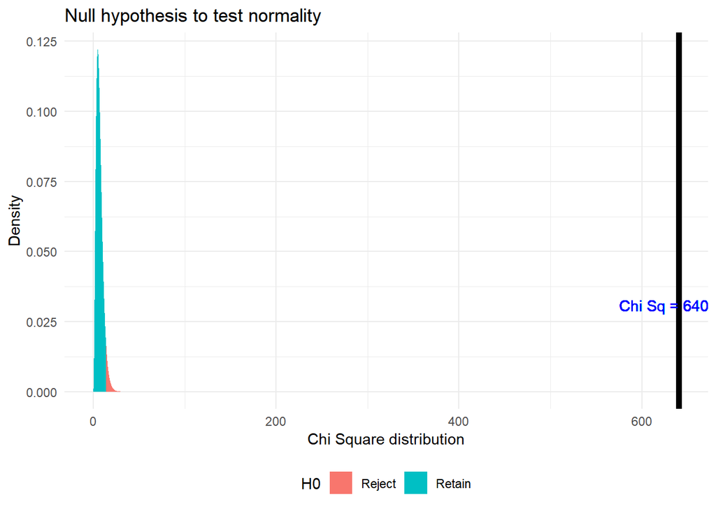

```r
chi.sq.plot(chi.sq = chi.test$statistic, df = chi.test$parameter, title = 'Null hypothesis to test normality')
```

As p < α, where α = 0.05, rejecting the Null hypothesis.

In the same post, I showed using qq plot how the distribution looks like a exponential distribution. To test if it is statistically significant, I will use the Chi-Square test.  
The chi-square goodness of fit test for each group would have the following hypothesis:  
H0: There is no statistically significant difference between the observed frequencies of ‘diff-in-time’ and expected frequencies from exponential distribution  
H1: There is a statistically significant difference

```r
minimum.dist <- min(data$alt.distr)
maximum.dist <- max(data$alt.distr)
n <- length(data$alt.distr)
lamda <- 1/mean(sd(data$alt.distr),mean(data$alt.distr))
range.group <- (maximum.dist - minimum.dist)/N
data <- data %>% mutate(class = floor(alt.distr/range.group),
                        class_name_min =  minimum.dist + class*range.group,
                        class_name_max = minimum.dist + (class+ 1)*range.group,
                        class_name = paste0(class_name_min, '-', class_name_max))
chi.sq.table <- data %>% group_by(class, class_name) %>% summarise(obs_freq = n(),
                                                                   class_name_min = mean(class_name_min),
                                                                   class_name_max = mean(class_name_max)) %>%
  mutate(exp_freq = pexp(class_name_max, lamda)*n - pexp(class_name_min, lamda)*n,
         chi.sq = ((obs_freq - exp_freq)^2)/exp_freq)
```

Cross Tabulation

| class | class_name | obs_freq | exp_freq | chi.sq |
| --- | --- | --- | --- | --- |
| 0 | 0-29 | 74 | 73.9534204 | 0.0000293 |
| 1 | 29-58 | 37 | 39.3388103 | 0.1390493 |
| 2 | 58-87 | 28 | 20.9259016 | 2.3914319 |
| 3 | 87-116 | 9 | 11.1313320 | 0.4080892 |
| 4 | 116-145 | 4 | 5.9212050 | 0.6233577 |
| 5 | 145-174 | 1 | 3.1497280 | 1.4672157 |
| 7 | 203-232 | 4 | 0.8912488 | 10.8435869 |
| 8 | 232-261 | 1 | 0.4740912 | 0.5833899 |

I observe that the expected frequency value is close to the observed frequency value in most of the cases.

```
##
##  Chi-squared test for given probabilities
##
## data:  chi.sq.table$obs_freq
## X-squared = 16.194, df = 7, p-value = 0.0234
```

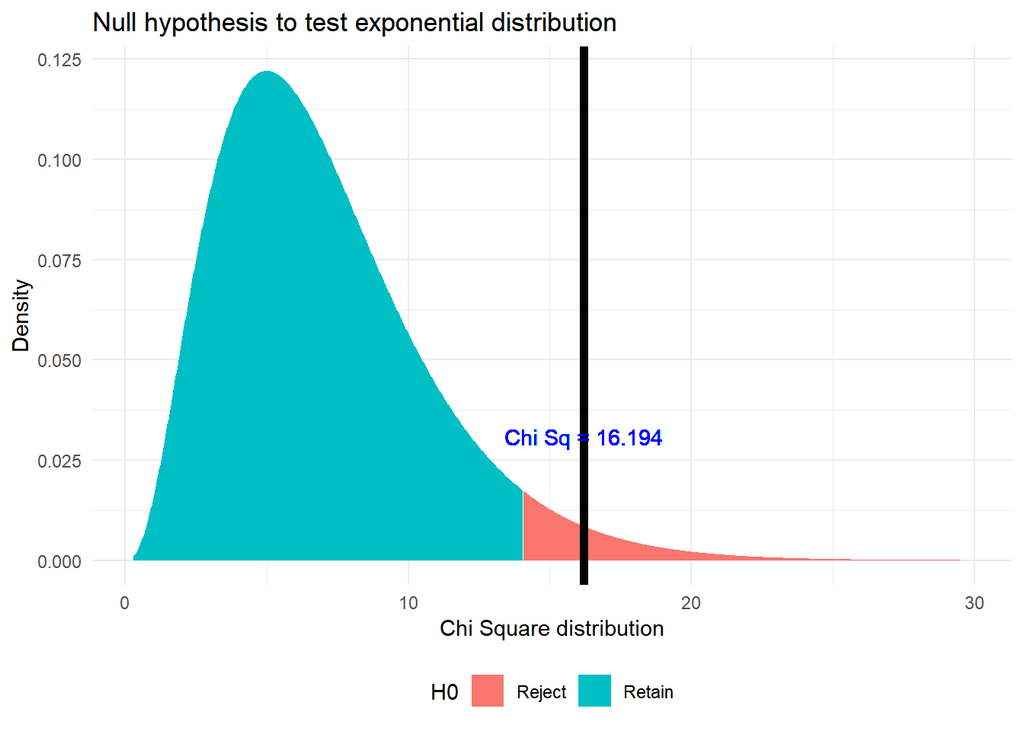

```
##
##  Chi-squared test for given probabilities
##
## data:  chi.sq.table$obs_freq
## X-squared = 2.8385, df = 3, p-value = 0.4172
```

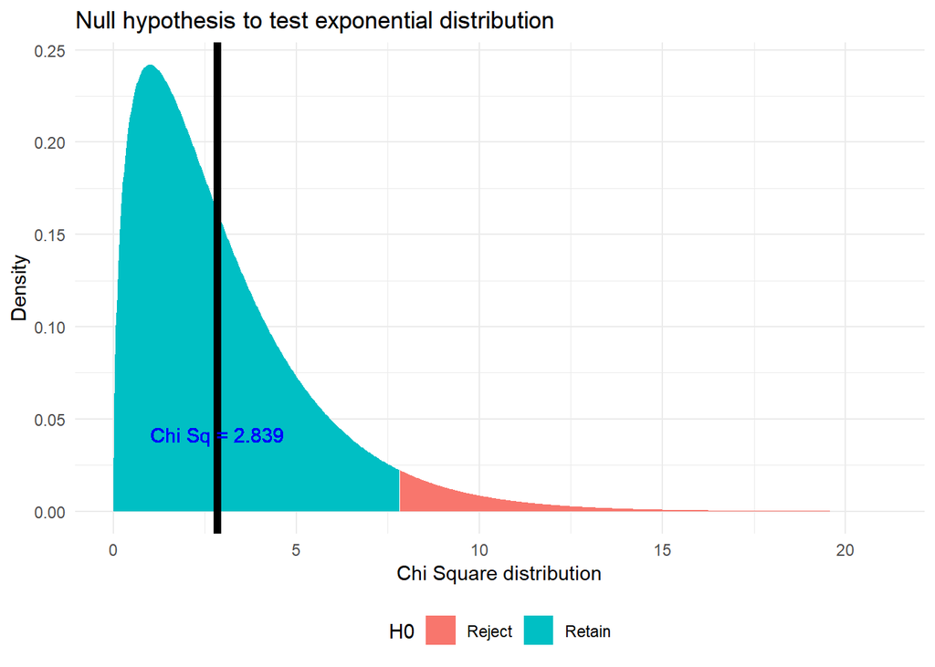

As p > α, where α = 0.05, retaining the Null hypothesis  
I want to find the effect size or the strength of relationship between these variables. That is explained by Cramers V by

```r
library(lsr)
cramersV(chi.sq.table$obs_freq, p = chi.sq.table$exp_freq, rescale.p = TRUE)
```

```
## [1] 0.03988245
```

For df=3 I have small effect = .06, medium effect = .17, large effect = .29 The current effect is very small.

Created on 23rd June 2019, Achyuthuni Sri Harsha